# Analyzing Differential Expression Across Conditions to Prioritize Clusters

Jack Collora

2023-07-06

# Objective

I have generated all of the comparisons of interest in a previous script (20230702FindingConditionMarkersAcrossConditions.R). Here I will process those results to try and identify any clusters that show a consistent change across modalities between conditions so that we can look into those further.

```r
suppressPackageStartupMessages(library(ggplot2))
suppressPackageStartupMessages(library(dplyr))
suppressPackageStartupMessages(library(Seurat))
suppressPackageStartupMessages(library(Signac))


results<-readRDS("~/gibbs/DOGMAMORPH/Ranalysis/Objects/20230606FinalObj.rds")
```

## RNA-seq results

Here I first examine the RNA-seq results. I want to know 1. which clusters have the greatest number of differentially expressed genes (total), 2. what is the direction of those genes (up or down), and 3. how does it differ by cluster comparison.

```r
data<-readRDS("~/gibbs/DOGMAMORPH/Ranalysis/Objects/20230702AllClustersTreatmentconditionsRNA.rds")

total_DE<-c()
for(cluster in data){
  DEs=0
  for (comparison in cluster){
    DEs=DEs+sum(comparison$p_val_adj<=0.05)
  }
  total_DE<-c(total_DE, DEs)
}
names(total_DE)<-names(data)
print(total_DE)
```

```
## Memory_CD4_Polarized_1          Naive_CD4_T_1                Naive_B
##                    500                    699                    129
##                    pDC            Cytotoxic_T               Memory_B
##                     35                    677                     24
##          Naive_CD4_T_3                     NK     Treg_proliferating
##                    535                    133                    298
##           Memory_CD4_1 Memory_CD4_Polarized_2             CD14+_Mono
##                    414                    413                    125
##                    cDC          Naive_CD4_T_2           Memory_CD4_2
##                     75                    125                      5
##                 Plasma
##                      3
```

```r
upDEs<-c()
downDEs<-c()

for(cluster in data){
  upDE=0
  downDE=0
  for (comparison in cluster){
    upDE=upDE+sum((comparison$p_val_adj<=0.05) & (comparison$avg_log2FC>0))
    downDE=downDE+sum((comparison$p_val_adj<=0.05) & (comparison$avg_log2FC<0))

  }
  upDEs<-c(upDEs, upDE)
  downDEs<-c(downDEs, downDE)
  }

names(upDEs)<-names(data)
print(upDEs)
```

```
## Memory_CD4_Polarized_1          Naive_CD4_T_1                Naive_B
##                    267                    342                     70
##                    pDC            Cytotoxic_T               Memory_B
##                     18                    411                     12
##          Naive_CD4_T_3                     NK     Treg_proliferating
##                    303                     94                    212
##           Memory_CD4_1 Memory_CD4_Polarized_2             CD14+_Mono
##                    178                    265                     92
##                    cDC          Naive_CD4_T_2           Memory_CD4_2
##                     11                     72                      1
##                 Plasma
##                      1
```

```r
names(downDEs)<-names(data)
print(downDEs)
```

```
## Memory_CD4_Polarized_1          Naive_CD4_T_1                Naive_B
##                    233                    357                     59
##                    pDC            Cytotoxic_T               Memory_B
##                     17                    266                     12
##          Naive_CD4_T_3                     NK     Treg_proliferating
##                    232                     39                     86
##           Memory_CD4_1 Memory_CD4_Polarized_2             CD14+_Mono
##                    236                    148                     33
##                    cDC          Naive_CD4_T_2           Memory_CD4_2
##                     64                     53                      4
##                 Plasma
##                      2
```

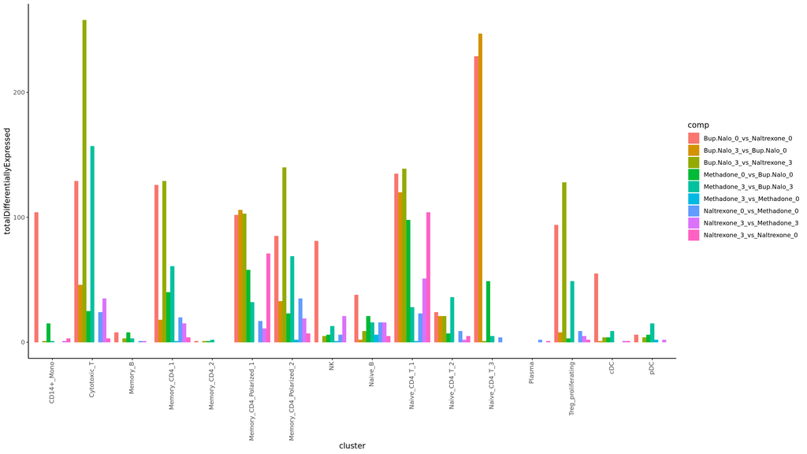

```r
data<-unlist(data, recursive = FALSE)

cond<-names(data)

totalDE<-function(dataframe){
  return(sum(dataframe$p_val_adj<0.05))
}

upDE<-function(dataframe){
  return(sum(dataframe$p_val_adj<0.05 & dataframe$avg_log2FC>0))
}

downDE<-function(dataframe){
  return(sum(dataframe$p_val_adj<0.05 & dataframe$avg_log2FC<0))
}

totalDifferentiallyExpressed<-unlist(lapply(data, totalDE))
res<-data.frame(cond,totalDifferentiallyExpressed)
res$upDE<-unlist(lapply(data, upDE))
res$downDE<-unlist(lapply(data, downDE))
res$cluster<-gsub(paste(c(".Methadone_3_vs_Methadone_0",   ".Bup.Nalo_3_vs_Bup.Nalo_0",     ".Naltrexone_3_vs_Naltrexone_0", ".Methadone_3_vs_Bup.Nalo_3",
".Bup.Nalo_3_vs_Naltrexone_3",   ".Naltrexone_3_vs_Methadone_3" , ".Methadone_0_vs_Bup.Nalo_0"  ,  ".Bup.Nalo_0_vs_Naltrexone_0"  ,
".Naltrexone_0_vs_Methadone_0"), collapse = "|"),"",res$cond)

res$comp<-gsub(paste(names(table(Idents(results))),".", collapse = "|", sep = ""),"",res$cond)
res$comp<-gsub("CD14\\+_Mono.","", res$comp)
res$modality<-"RNA"

ggplot(res, aes(x=cluster, y=totalDifferentiallyExpressed, fill=comp))+geom_col(position="dodge")+theme_classic()+theme(axis.text.x = element_text(vjust = 0.3, angle = 90, hjust=1))
```

There doesnt seem to be a polarization between up and down regulation, which is nice to see. it’s suggestive that we’re seeing distinct signatures.

Based on the differences across clusters, it looks like Cytotoxic T are genuinely the most nteresting across conditions. We also see significant baseline differences between Bup.Nalo_0 and Naltrexone_0. From this other clusters that are intersting include Memory CD4_polarized 1/2 and Naive CD4_T_1, and possible the Treg proliferating cluster. Other unbalanced clusters (monocytes and whatnot) are not overall different accross conditions in any interesting degrees.

## ATAC

Here we want to look for the same thing as above, just trying it wth the ATAC figures. I’ll make a different “res” frame so that I can combine them at the end.

```r
data<-readRDS("~/gibbs/DOGMAMORPH/Ranalysis/Objects/20230702AllClustersTreatmentconditionsATAC.rds")

total_DE<-c()
for(cluster in data){
  DEs=0
  for (comparison in cluster){
    DEs=DEs+sum(comparison$p_val_adj<=0.05)
  }
  total_DE<-c(total_DE, DEs)
}
names(total_DE)<-names(data)
print(total_DE)
```

```
## Memory_CD4_Polarized_1          Naive_CD4_T_1                Naive_B
##                     21                     68                      3
##                    pDC            Cytotoxic_T               Memory_B
##                      1                      4                      1
##          Naive_CD4_T_3                     NK     Treg_proliferating
##                      2                      0                      2
##           Memory_CD4_1 Memory_CD4_Polarized_2             CD14+_Mono
##                      2                     54                      0
##                    cDC          Naive_CD4_T_2           Memory_CD4_2
##                      0                      3                      0
##                 Plasma
##                      0
```

```r
upDEs<-c()
downDEs<-c()

for(cluster in data){
  upDE=0
  downDE=0
  for (comparison in cluster){
    upDE=upDE+sum((comparison$p_val_adj<=0.05) & (comparison$avg_log2FC>0))
    downDE=downDE+sum((comparison$p_val_adj<=0.05) & (comparison$avg_log2FC<0))

  }
  upDEs<-c(upDEs, upDE)
  downDEs<-c(downDEs, downDE)
  }

names(upDEs)<-names(data)
print(upDEs)
```

```
## Memory_CD4_Polarized_1          Naive_CD4_T_1                Naive_B
##                      9                     15                      2
##                    pDC            Cytotoxic_T               Memory_B
##                      0                      3                      1
##          Naive_CD4_T_3                     NK     Treg_proliferating
##                      1                      0                      1
##           Memory_CD4_1 Memory_CD4_Polarized_2             CD14+_Mono
##                      0                     25                      0
##                    cDC          Naive_CD4_T_2           Memory_CD4_2
##                      0                      1                      0
##                 Plasma
##                      0
```

```r
names(downDEs)<-names(data)
print(downDEs)
```

```
## Memory_CD4_Polarized_1          Naive_CD4_T_1                Naive_B
##                     12                     53                      1
##                    pDC            Cytotoxic_T               Memory_B
##                      1                      1                      0
##          Naive_CD4_T_3                     NK     Treg_proliferating
##                      1                      0                      1
##           Memory_CD4_1 Memory_CD4_Polarized_2             CD14+_Mono
##                      2                     29                      0
##                    cDC          Naive_CD4_T_2           Memory_CD4_2
##                      0                      2                      0
##                 Plasma
##                      0
```

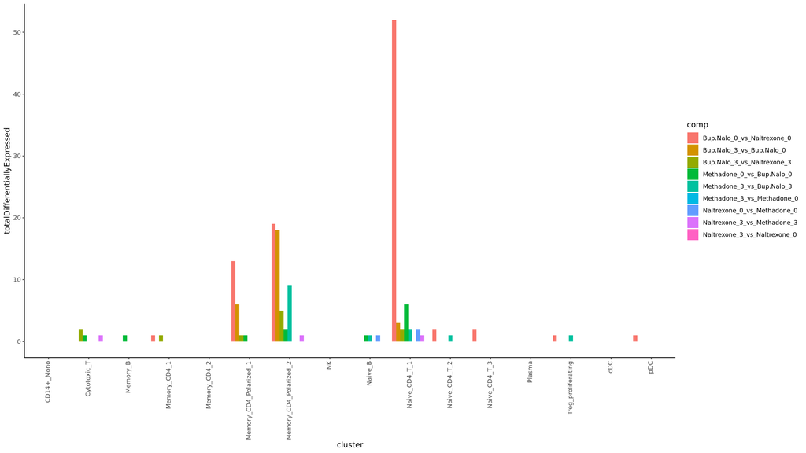

```r
data<-unlist(data, recursive = FALSE)

cond<-names(data)

totalDE<-function(dataframe){
  return(sum(dataframe$p_val_adj<0.05))
}

upDE<-function(dataframe){
  return(sum(dataframe$p_val_adj<0.05 & dataframe$avg_log2FC>0))
}

downDE<-function(dataframe){
  return(sum(dataframe$p_val_adj<0.05 & dataframe$avg_log2FC<0))
}

totalDifferentiallyExpressed<-unlist(lapply(data, totalDE))
res2<-data.frame(cond,totalDifferentiallyExpressed)
res2$upDE<-unlist(lapply(data, upDE))
res2$downDE<-unlist(lapply(data, downDE))
res2$cluster<-gsub(paste(c(".Methadone_3_vs_Methadone_0",   ".Bup.Nalo_3_vs_Bup.Nalo_0",     ".Naltrexone_3_vs_Naltrexone_0", ".Methadone_3_vs_Bup.Nalo_3",
".Bup.Nalo_3_vs_Naltrexone_3",   ".Naltrexone_3_vs_Methadone_3" , ".Methadone_0_vs_Bup.Nalo_0"  ,  ".Bup.Nalo_0_vs_Naltrexone_0"  ,
".Naltrexone_0_vs_Methadone_0"), collapse = "|"),"",res2$cond)

res2$comp<-gsub(paste(names(table(Idents(results))),".", collapse = "|", sep = ""),"",res2$cond)
res2$comp<-gsub("CD14\\+_Mono.","", res2$comp)
res2$modality<-"ATAC"

ggplot(res2, aes(x=cluster, y=totalDifferentiallyExpressed, fill=comp))+geom_col(position="dodge")+theme_classic()+theme(axis.text.x = element_text(vjust = 0.3, angle = 90, hjust=1))
```

ATAC-seq has basically no differencces across conditions. How bizzare that we see so few statistically significant differences. We can find differences between clusters but between individuals there are virtually no changes in accessibility within populations.

Of those with differences, we see these primarily within the polarized and naive populations.

Overall these results suggest that we’re seeing a limited impact on chromatin accessibility across the conditions.

## Chromvar

Here we want to look for the same thing as above, just trying it wth the Chromvar figures. I’ll make a different “res” frame so that I can combine them at the end.

```r
data<-readRDS("~/gibbs/DOGMAMORPH/Ranalysis/Objects/20230702AllClustersTreatmentconditionschromVAR.rds")

total_DE<-c()
for(cluster in data){
  DEs=0
  for (comparison in cluster){
    DEs=DEs+sum(comparison$p_val_adj<=0.05)
  }
  total_DE<-c(total_DE, DEs)
}
names(total_DE)<-names(data)
print(total_DE)
```

```
## Memory_CD4_Polarized_1          Naive_CD4_T_1                Naive_B
##                    337                    455                     69
##                    pDC            Cytotoxic_T               Memory_B
##                     36                    239                     12
##          Naive_CD4_T_3                     NK     Treg_proliferating
##                    184                    123                    222
##           Memory_CD4_1 Memory_CD4_Polarized_2             CD14+_Mono
##                    191                    426                    176
##                    cDC          Naive_CD4_T_2           Memory_CD4_2
##                      7                     54                     14
##                 Plasma
##                      6
```

```r
upDEs<-c()
downDEs<-c()

for(cluster in data){
  upDE=0
  downDE=0
  for (comparison in cluster){
    upDE=upDE+sum((comparison$p_val_adj<=0.05) & (comparison$avg_diff>0))
    downDE=downDE+sum((comparison$p_val_adj<=0.05) & (comparison$avg_diff<0))

  }
  upDEs<-c(upDEs, upDE)
  downDEs<-c(downDEs, downDE)
  }

names(upDEs)<-names(data)
print(upDEs)
```

```
## Memory_CD4_Polarized_1          Naive_CD4_T_1                Naive_B
##                    159                    199                     31
##                    pDC            Cytotoxic_T               Memory_B
##                      7                    112                      6
##          Naive_CD4_T_3                     NK     Treg_proliferating
##                    108                     56                    102
##           Memory_CD4_1 Memory_CD4_Polarized_2             CD14+_Mono
##                     77                    229                    148
##                    cDC          Naive_CD4_T_2           Memory_CD4_2
##                      6                     29                      7
##                 Plasma
##                      3
```

```r
names(downDEs)<-names(data)
print(downDEs)
```

```
## Memory_CD4_Polarized_1          Naive_CD4_T_1                Naive_B
##                    178                    256                     38
##                    pDC            Cytotoxic_T               Memory_B
##                     29                    127                      6
##          Naive_CD4_T_3                     NK     Treg_proliferating
##                     76                     67                    120
##           Memory_CD4_1 Memory_CD4_Polarized_2             CD14+_Mono
##                    114                    197                     28
##                    cDC          Naive_CD4_T_2           Memory_CD4_2
##                      1                     25                      7
##                 Plasma
##                      3
```

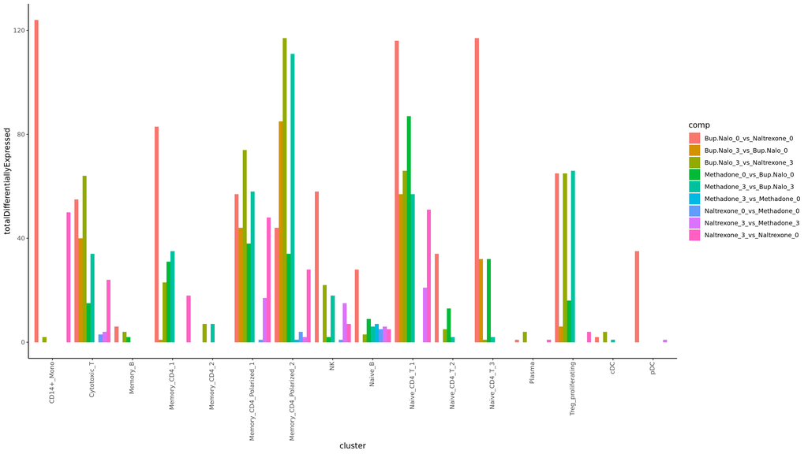

```r
data<-unlist(data, recursive = FALSE)

cond<-names(data)

totalDE<-function(dataframe){
  return(sum(dataframe$p_val_adj<0.05))
}

upDE<-function(dataframe){
  return(sum(dataframe$p_val_adj<0.05 & dataframe$avg_diff>0))
}

downDE<-function(dataframe){
  return(sum(dataframe$p_val_adj<0.05 & dataframe$avg_diff<0))
}

totalDifferentiallyExpressed<-unlist(lapply(data, totalDE))
res3<-data.frame(cond,totalDifferentiallyExpressed)
res3$upDE<-unlist(lapply(data, upDE))
res3$downDE<-unlist(lapply(data, downDE))
res3$cluster<-gsub(paste(c(".Methadone_3_vs_Methadone_0",   ".Bup.Nalo_3_vs_Bup.Nalo_0",     ".Naltrexone_3_vs_Naltrexone_0", ".Methadone_3_vs_Bup.Nalo_3",
".Bup.Nalo_3_vs_Naltrexone_3",   ".Naltrexone_3_vs_Methadone_3" , ".Methadone_0_vs_Bup.Nalo_0"  ,  ".Bup.Nalo_0_vs_Naltrexone_0"  ,
".Naltrexone_0_vs_Methadone_0"), collapse = "|"),"",res3$cond)

res3$comp<-gsub(paste(names(table(Idents(results))),".", collapse = "|", sep = ""),"",res3$cond)
res3$comp<-gsub("CD14\\+_Mono.","", res3$comp)
res3$modality<-"chromvar"

ggplot(res3, aes(x=cluster, y=totalDifferentiallyExpressed, fill=comp))+geom_col(position="dodge")+theme_classic()+theme(axis.text.x = element_text(vjust = 0.3, angle = 90, hjust=1))
```

As with the RNA, the most interesting clusters are these that are polarized and naive CD4 across conditions. So I guess it makes the most sense to evaluate those four more closely and see what we can say about them. It’s obvious that the RNA and chromvar are the only ones that make sense to look much more closely at since they are the only ones that have a difference across conditions, while ATAC is very information poor here. This is also likely why the linkage analysis was not fruitful.

## multimodality differences

Now we’re just going to sum the features across conditions to see if any populations become interesting when we look more closely.

```r
res<-rbind(res, res2, res3)
res_meta<-group_by(res, cluster, comp, cond)%>%summarise(n=sum(totalDifferentiallyExpressed))
```

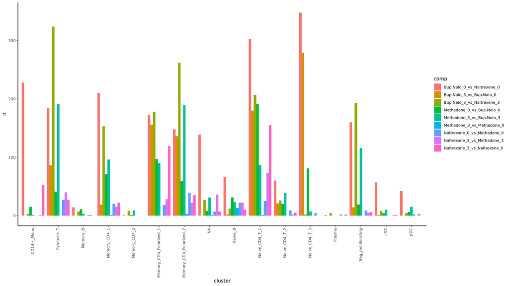

```r
ggplot(res_meta, aes(x=cluster, y=n, fill=comp))+geom_col(position="dodge")+theme_classic()+theme(axis.text.x = element_text(vjust = 0.3, angle = 90, hjust=1))
```